# Day 3: Linear Regression

Always start your R session by setting up the necessary libraries:

```r
# Load packages
library(tidyverse)
library(palmerpenguins)
```

When building models, we can only learn from non-missing values, let’s ignore those for now:

```r
# Save a version of the penguins dataset, removing any missing values
penguins_clean <- as.data.frame(penguins) |>
  # Filter any missing values
  na.omit()
```

## 1. Simple Linear Regression

> Research Question: Can we estimate a penguin’s body mass based on its flipper length?

### a. Visualizing the model

We can use the `lm` method to visualize a linear model:

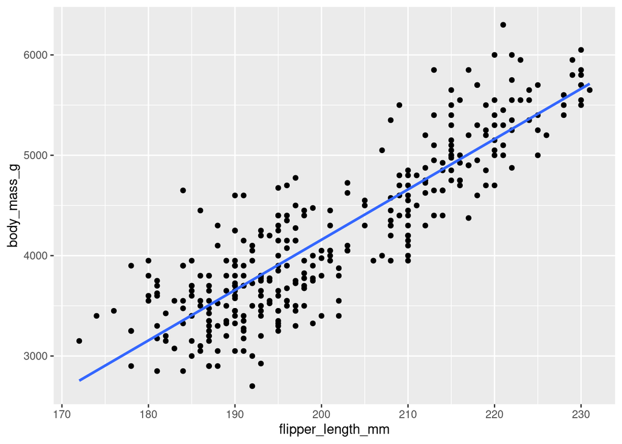

```r
penguins_clean |>
  # Make a plot
  ggplot() +
  # Scatterplot
  geom_point(aes(x = flipper_length_mm, y = body_mass_g)) +
  # Visualize regression line
  geom_smooth(aes(x = flipper_length_mm, y = body_mass_g),
              method = "lm", se = FALSE)
```

How did R choose what line to fit this data?

### b. Fitting a model

If we suspect there is a linear relationship between two variables, we can consider a linear model:

```r
# Fit the model: response ~ predictor
fit_model <- lm(body_mass_g ~ flipper_length_mm, data = penguins_clean)

# Take a look at the model summary
summary(fit_model)
```

```
##
## Call:
## lm(formula = body_mass_g ~ flipper_length_mm, data = penguins_clean)
##
## Residuals:
##      Min       1Q   Median       3Q      Max
## -1057.33  -259.79   -12.24   242.97  1293.89
##
## Coefficients:
##                   Estimate Std. Error t value Pr(>|t|)
## (Intercept)       -5872.09     310.29  -18.93   <2e-16 ***
## flipper_length_mm    50.15       1.54   32.56   <2e-16 ***
## ---
## Signif. codes:  0 '***' 0.001 '**' 0.01 '*' 0.05 '.' 0.1 ' ' 1
##
## Residual standard error: 393.3 on 331 degrees of freedom
## Multiple R-squared:  0.7621, Adjusted R-squared:  0.7614
## F-statistic:  1060 on 1 and 331 DF,  p-value: < 2.2e-16
```

This output tells us a lot of things. First, it gives us the estimates of the model:

$\widehat{mass} = -5872.09 + 50.15 * flipper_length$

Note: We use the hat to specify that we get predicted values of the response variable (as opposed to `body_mass_g`, the observed values in the dataset).

### c. Predicting values

We can use the equation above to predict values or use an R function:

```r
penguins_clean |>
  # Calculate predicted values
  mutate(predicted = predict(fit_model)) |>
  # Just show the variables of interest
  select(flipper_length_mm, body_mass_g , predicted)
```

```
##     flipper_length_mm body_mass_g predicted
## 1                 181        3750  3205.648
## 2                 186        3800  3456.415
## 3                 195        3250  3907.794
## 5                 193        3450  3807.488
## 6                 190        3650  3657.028
## 7                 181        3625  3205.648
## 8                 195        4675  3907.794
## 13                182        3200  3255.802
## 14                191        3800  3707.181
## 15                198        4400  4058.254
## 16                185        3700  3406.262
## 17                195        3450  3907.794
## 18                197        4500  4008.101
## 19                184        3325  3356.108
```

[output cut: 319 more lines]

We can also find predicted values for new data with only the values for the predictor:

```r
# Find predicted values for new data
predict(fit_model, newdata = data.frame(flipper_length_mm = 185))
```

```
##        1
## 3406.262
```

*Note: the `predict()` function only works if the predictor(s) have no missing values.*

### d. Residuals

Our predicted values don’t usually match exactly our observed values. The residuals represent the difference between observed values and predicted values:

```r
penguins_clean |>
  # First add predicted values based on model
  mutate(predicted = predict(fit_model)) |>
  # Calculate residuals = observed - predicted
  mutate(residual = resid(fit_model)) |>
  # Just show the variables of interest
  select(flipper_length_mm, body_mass_g , predicted, residual)
```

```
##     flipper_length_mm body_mass_g predicted     residual
## 1                 181        3750  3205.648   544.351547
## 2                 186        3800  3456.415   343.585218
## 3                 195        3250  3907.794  -657.794176
## 5                 193        3450  3807.488  -357.487644
## 6                 190        3650  3657.028    -7.027846
## 7                 181        3625  3205.648   419.351547
## 8                 195        4675  3907.794   767.205824
## 13                182        3200  3255.802   -55.801719
## 14                191        3800  3707.181    92.818888
## 15                198        4400  4058.254   341.746026
## 16                185        3700  3406.262   293.738484
## 17                195        3450  3907.794  -457.794176
## 18                197        4500  4008.101   491.899292
## 19                184        3325  3356.108   -31.108251
```

[output cut: 319 more lines]

Let’s visualize the residuals:

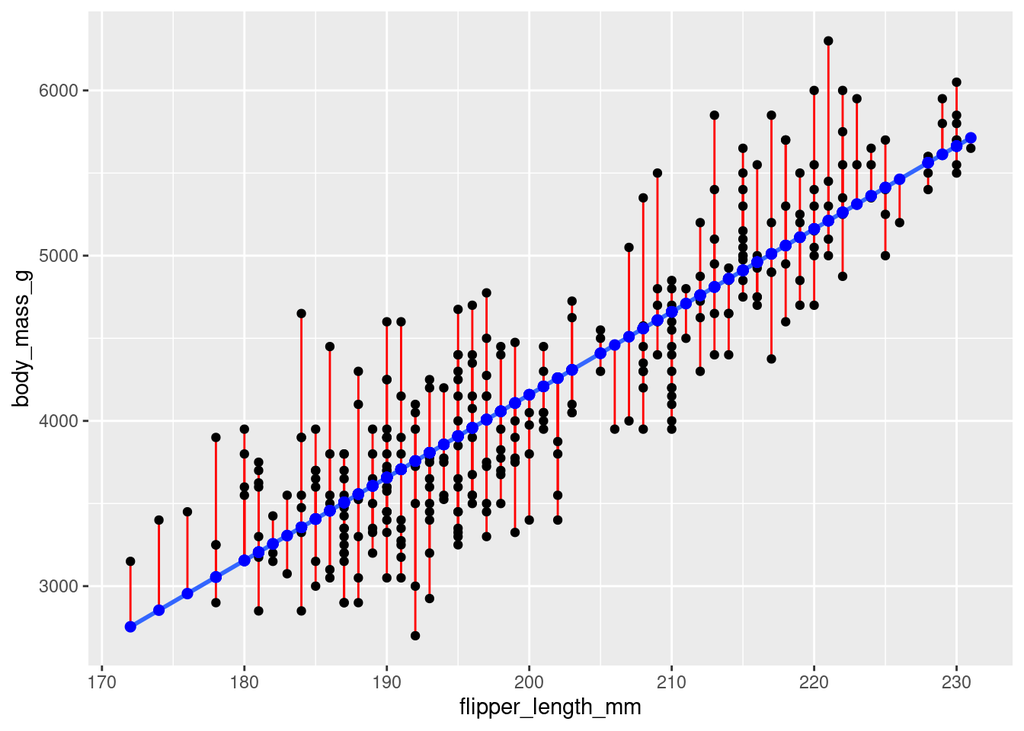

```r
penguins_clean |>
  # First add predicted values based on model
  mutate(predicted = predict(fit_model)) |>
  # Calculate residuals = observed - predicted
  mutate(residual = resid(fit_model)) |>
  # Use a ggplot to represent the relationship
  ggplot(aes(x = flipper_length_mm, y = body_mass_g)) +
  # Add the linear model
  geom_smooth(method = "lm", se = FALSE) +
  # Add residuals = vertical segments from observations to predicted
  geom_segment(aes(xend = flipper_length_mm, yend = predicted), color = "red") +
  # Display the observed data
  geom_point() +
  # Display the predicted (on top of the line)
  geom_point(aes(y = predicted), size = 2, color = "blue")
```

A linear regression model is built by minimizing the sum of squared residuals.

#### **Try it! Find the mean of the predicted values and mean of body mass. Why does it make sense to get this value?**

```r
# Write and submit code here!
penguins_clean |>
  # First add predicted values based on model
  mutate(predicted = predict(fit_model)) |>
  # Calculate residuals = observed - predicted
  mutate(residual = resid(fit_model)) |>
  summarize(mean(predicted),
            mean(body_mass_g),
            mean(residual))
```

```
##   mean(predicted) mean(body_mass_g) mean(residual)
## 1        4207.057          4207.057   4.394616e-14
```

The mean of predicted values is equal to the mean of observed body mass. This always happens in simple linear regression because the regression line goes through the point (mean of x, mean of y).

### e. Assessing Assumptions

In addition to the assumption of a random sample, to validate the use of a simple linear regression model, we should check the following assumptions:

- Linearity: The relationship between the predictor and the response is linear.
- Independence of observations: Observations should be independent of each other.
- Normality of residuals: The residuals are approximately normally distributed.
- Equal variance (Homoscedasticity): The variability of the residuals is roughly the same across all fitted values.

We can assess these assumptions using the following plots:

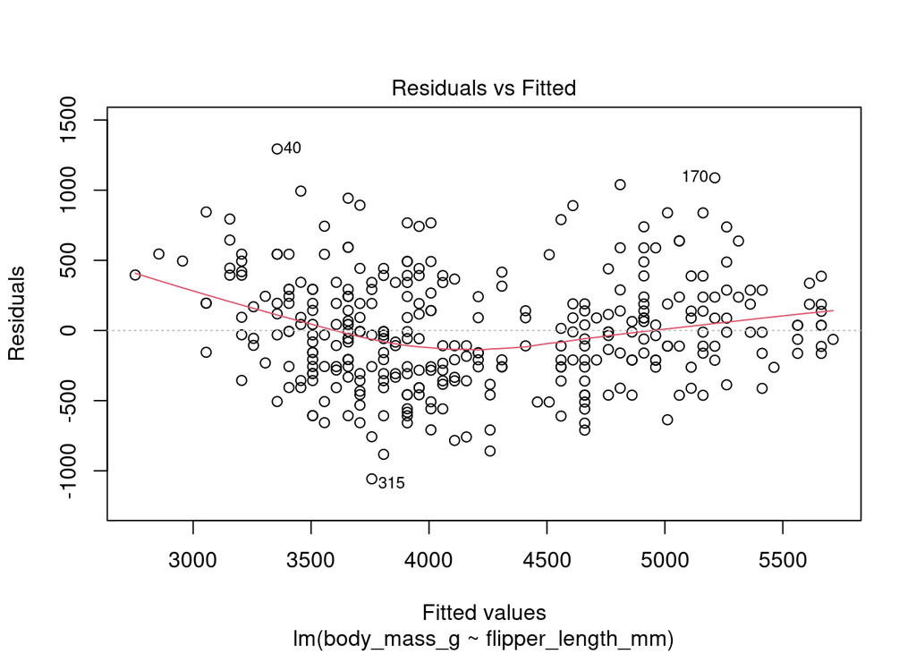

```r
# Residuals vs. Fitted values: checks for linearity and constant variance
plot(fit_model, which = 1)
```

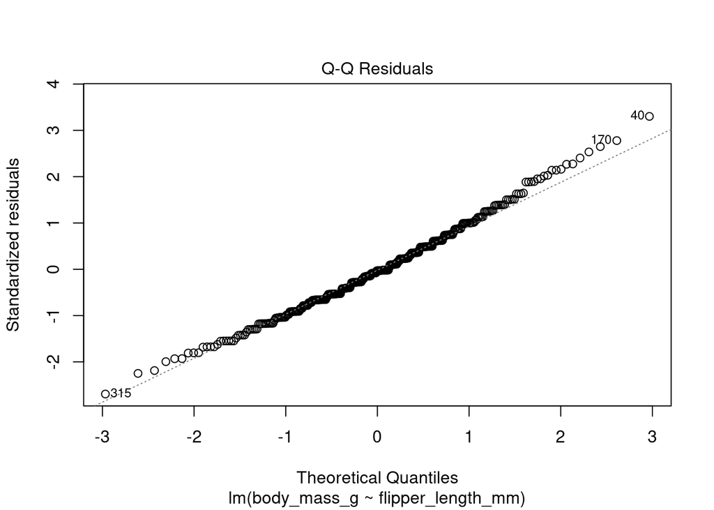

```r
# Q-Q Residuals: checks if residuals are normally distributed
plot(fit_model, which = 2)
```

There is no clear violation of the assumptions so the assumptions can be considered to be met.

### f. Inference

The notation $\beta_1$ refers to the slope for the population of penguins. Then the hypotheses to test about the significance of the slope are:

1. Hypotheses:
- H0: The population slope between body mass and flipper length is 0
- Ha: The population slope between body mass and flipper length is not 0
2. To find descriptive statistics and 3. Compare the estimate to the claim, we use the model summary:

```r
# Take another look at the model summary
summary(fit_model)
```

```
##
## Call:
## lm(formula = body_mass_g ~ flipper_length_mm, data = penguins_clean)
##
## Residuals:
##      Min       1Q   Median       3Q      Max
## -1057.33  -259.79   -12.24   242.97  1293.89
##
## Coefficients:
##                   Estimate Std. Error t value Pr(>|t|)
## (Intercept)       -5872.09     310.29  -18.93   <2e-16 ***
## flipper_length_mm    50.15       1.54   32.56   <2e-16 ***
## ---
## Signif. codes:  0 '***' 0.001 '**' 0.01 '*' 0.05 '.' 0.1 ' ' 1
##
## Residual standard error: 393.3 on 331 degrees of freedom
## Multiple R-squared:  0.7621, Adjusted R-squared:  0.7614
## F-statistic:  1060 on 1 and 331 DF,  p-value: < 2.2e-16
```

This data provides evidence that flipper length is a significant linear predictor of body mass (t = 32.56, df = 331, p < 0.001).

If the slope is significantly different from 0, we can report a confidence interval:

```r
# Calculates 95% confidence intervals for the coefficients
confint(fit_model, level = 0.95)
```

```
##                         2.5 %      97.5 %
## (Intercept)       -6482.47224 -5261.71313
## flipper_length_mm    47.12339    53.18314
```

For every additional millimeter increase in flipper length, the body mass is expected to increase by between 47.1 to 53.2 grams, on average, at the 95% confidence level.

We can also build a confidence intervals for predicted values:

```r
# Find predicted values for new data
predict(fit_model, newdata = data.frame(flipper_length_mm = 185), interval = "confidence")
```

```
##        fit      lwr      upr
## 1 3406.262 3341.931 3470.592
```

Penguins with a flipper length of 185 mm have a predicted mean body mass between 3341.9 and 3470.6 grams, at the 95% confidence level.

We can add the confidence intervals for predictions when we visualize the linear model:

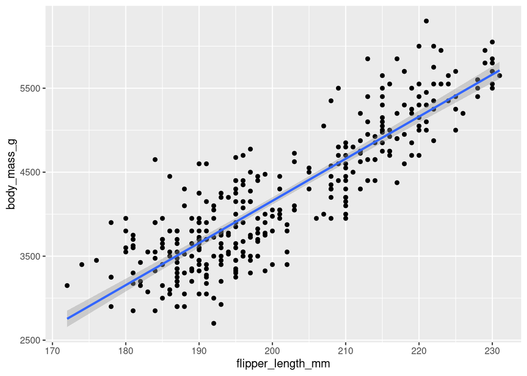

```r
penguins_clean |>
  # Make a plot
  ggplot() +
  # Scatterplot
  geom_point(aes(x = flipper_length_mm, y = body_mass_g)) +
  # Visualize regression line with confidence interval
  geom_smooth(aes(x = flipper_length_mm, y = body_mass_g),
              method = "lm", se = TRUE)
```

Lastly, we can also provide a prediction interval for a predicted value of an individual:

```r
# Find predicted values for new data
predict(fit_model, newdata = data.frame(flipper_length_mm = 185), interval = "prediction")
```

```
##        fit      lwr      upr
## 1 3406.262 2629.824 4182.699
```

A penguin with a flipper length of 185 mm has a predicted body mass between 2629.8 and 4182.7 grams, at the 95% confidence level.

### g. Performance

To quantify performance for linear regression models, we can consider several metrics:

- the coefficient of determination $R^2$ which reports the percentage of variation in the response variable that can be explained by the predictor variable:

```r
# Report adjusted R-squared of regression model
summary(fit_model)$adj.r.squared
```

```
## [1] 0.7613734
```

About 76% of the variation in body mass can be explained by the variation in flipper length. The higher the $R^2$, the better a model fits a dataset. Note that $R^2$ represents a proportion between 0 and 1.

- the Mean Square Error (MSE) which measures the average squared differences between predicted and observed values:

```r
# Calculate MSE of regression model: mean of residuals squared
mean(resid(fit_model)^2)
```

```
## [1] 153789.7
```

- the Root Mean Square Error (RMSE) which is the square root of the MSE and measures the average distance between predicted and observed values in the dataset:

```r
# Calculate RMSE of regression model: square root of mean residuals squared
sqrt(mean(resid(fit_model)^2))
```

```
## [1] 392.1603
```

```r
sd(penguins_clean$body_mass_g)
```

```
## [1] 805.2158
```

The lower the RMSE, the better a model fits a dataset and the more reliable our predicted values can be. Note that the RMSE is reported in the same unit as the **response** variable.

#### **Try it! Choose a different numeric variable (other than flipper length) to predict body mass:**

- **Is this new predictor significantly associated with body mass?**
- **Do the model assumptions appear to be satisfied?**
- **How does this model compare to the one using flipper length: is it better at predicting body mass?**

```r
# Use bill length as another predictor
fit_model <- lm(body_mass_g ~ bill_length_mm, data = penguins_clean)

# Model summary
summary(fit_model)
```

```
##
## Call:
## lm(formula = body_mass_g ~ bill_length_mm, data = penguins_clean)
##
## Residuals:
##      Min       1Q   Median       3Q      Max
## -1759.38  -468.82    27.79   464.20  1641.00
##
## Coefficients:
##                Estimate Std. Error t value Pr(>|t|)
## (Intercept)     388.845    289.817   1.342    0.181
## bill_length_mm   86.792      6.538  13.276   <2e-16 ***
## ---
## Signif. codes:  0 '***' 0.001 '**' 0.01 '*' 0.05 '.' 0.1 ' ' 1
##
## Residual standard error: 651.4 on 331 degrees of freedom
## Multiple R-squared:  0.3475, Adjusted R-squared:  0.3455
## F-statistic: 176.2 on 1 and 331 DF,  p-value: < 2.2e-16
```

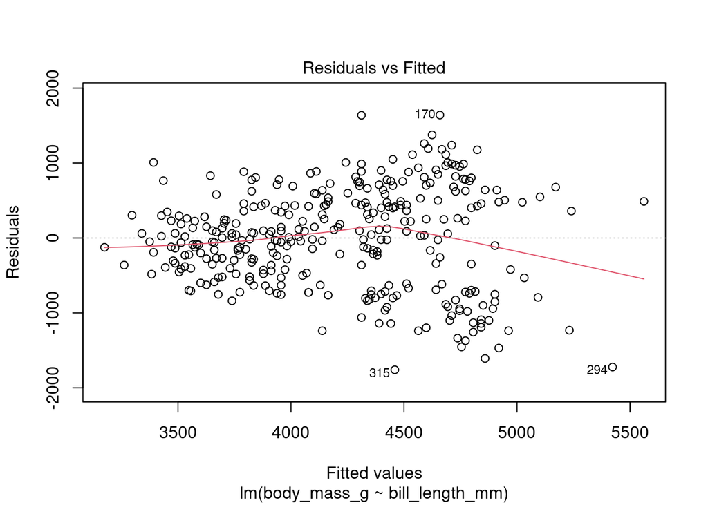

```r
# Model assumptions
plot(fit_model, which = 1)
```

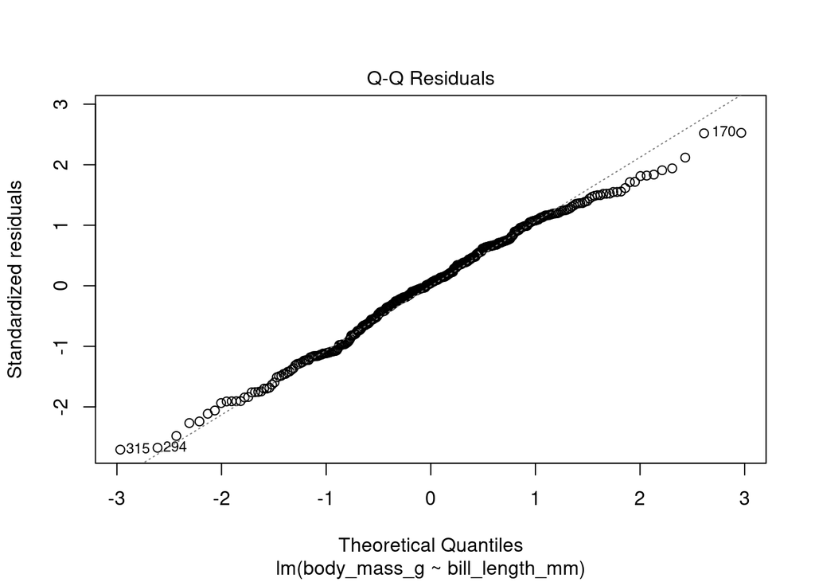

```r
plot(fit_model, which = 2)
```

Bill length is a significant linear predictor of body mass (t = 13.3, df = 331, p < 0.001), however, there seems to be an issue with the assumption of equal variance. Previously, Multiple R-squared was 0.7621 and now it is 0.3475: a lot less variation in body mass is explained by bill length compared to flipper length. The first model (using flipper length as a predictor) would be better at predicting body mass.

## 2. Connection to ANOVA

ANOVA and Regression use the same math under the hood!

```r
# Linear Regression
fit_model <- lm(body_mass_g ~ flipper_length_mm, data = penguins_clean)
summary(fit_model)
```

```
##
## Call:
## lm(formula = body_mass_g ~ flipper_length_mm, data = penguins_clean)
##
## Residuals:
##      Min       1Q   Median       3Q      Max
## -1057.33  -259.79   -12.24   242.97  1293.89
##
## Coefficients:
##                   Estimate Std. Error t value Pr(>|t|)
## (Intercept)       -5872.09     310.29  -18.93   <2e-16 ***
## flipper_length_mm    50.15       1.54   32.56   <2e-16 ***
## ---
## Signif. codes:  0 '***' 0.001 '**' 0.01 '*' 0.05 '.' 0.1 ' ' 1
##
## Residual standard error: 393.3 on 331 degrees of freedom
## Multiple R-squared:  0.7621, Adjusted R-squared:  0.7614
## F-statistic:  1060 on 1 and 331 DF,  p-value: < 2.2e-16
```

```r
# ANOVA
anova_model <- aov(body_mass_g ~ flipper_length_mm, data = penguins_clean)
summary(anova_model)
```

```
##                    Df    Sum Sq   Mean Sq F value Pr(>F)
## flipper_length_mm   1 164047703 164047703    1060 <2e-16 ***
## Residuals         331  51211963    154719
## ---
## Signif. codes:  0 '***' 0.001 '**' 0.01 '*' 0.05 '.' 0.1 ' ' 1
```

ANOVA and regression both rely on decomposing variation in the response variable into components. In simple linear regression, we split the total variation in body_mass_g into variation explained by flipper_length_mm (the regression model) and unexplained variation (residuals). The ANOVA table shows these components using sums of squares and reports an F-test to evaluate whether the model explains a significant amount of variability in the response. This is the same F-test reported in the regression summary. So, ANOVA and regression are not separate techniques: they are two lenses to view the same underlying model.

## 3. Multiple Regression

> Research Question: Can we estimate a penguin’s bill depth based on its bill length for different species?

### a. Visualizing the model

With 3 variables, the visualization becomes tricky but it is still manageable with 2 numeric and 1 categorical variables:

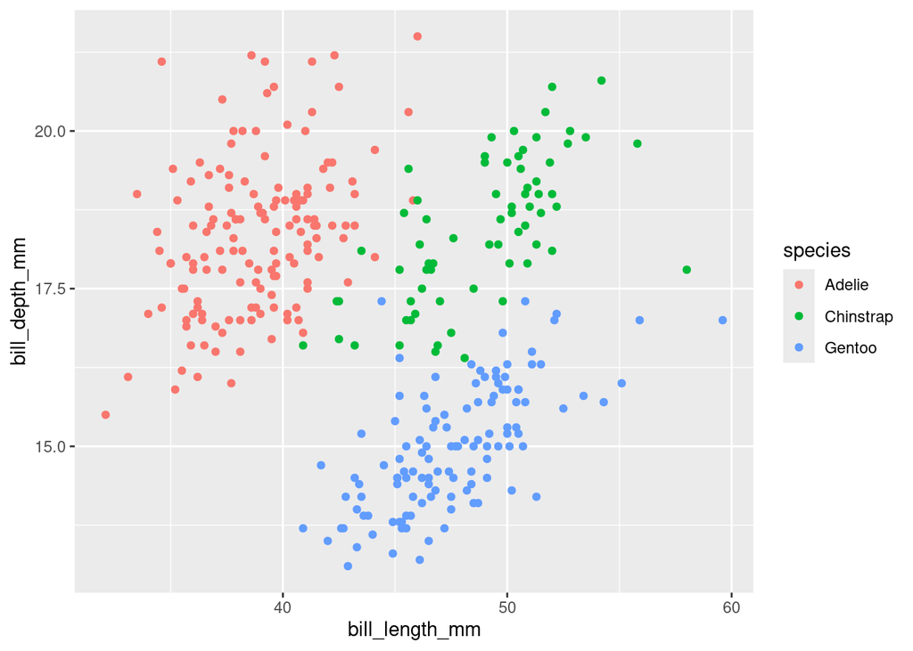

```r
penguins_clean |>
  # Make a plot
  ggplot() +
  # Scatterplot
  geom_point(aes(x = bill_length_mm, y = bill_depth_mm, color = species))
```

```r
  # There is no easy way to visualize the regression line for each species
```

### b. Fitting a model

Let’s fit this linear model:

```r
# Fit the model: response ~ predictors
fit_model <- lm(bill_depth_mm ~ bill_length_mm + species, data = penguins_clean)

# Take a look at the model summary
summary(fit_model)
```

```
##
## Call:
## lm(formula = bill_depth_mm ~ bill_length_mm + species, data = penguins_clean)
##
## Residuals:
##     Min      1Q  Median      3Q     Max
## -2.4579 -0.6814 -0.0431  0.5441  3.5994
##
## Coefficients:
##                  Estimate Std. Error t value Pr(>|t|)
## (Intercept)      10.56526    0.69093  15.291  < 2e-16 ***
## bill_length_mm    0.20044    0.01768  11.337  < 2e-16 ***
## speciesChinstrap -1.93308    0.22572  -8.564 4.26e-16 ***
## speciesGentoo    -5.10332    0.19440 -26.252  < 2e-16 ***
## ---
## Signif. codes:  0 '***' 0.001 '**' 0.01 '*' 0.05 '.' 0.1 ' ' 1
##
## Residual standard error: 0.9543 on 329 degrees of freedom
## Multiple R-squared:  0.7673, Adjusted R-squared:  0.7652
## F-statistic: 361.6 on 3 and 329 DF,  p-value: < 2.2e-16
```

We can write the equation for this model:

$\widehat{bill_depth} = 10.56526 + 0.20044 * bill_length - 1.93308 * Chinstrap - 5.10332 * Gentoo$

Note: The categories for species have been switched to dummy variables. One of the categories (first in alphabetical order) is set as the reference.

If a penguin in Adelie:

$\widehat{bill_depth} = 10.56526 + 0.20044 * bill_length$

If a penguin is Chinstrap:

$\widehat{bill_depth} = 10.56526 + 0.20044 * bill_length - 1.93308 * 1$

If a penguin is Gentoo:

$\widehat{bill_depth} = 10.56526 + 0.20044 * bill_length - 5.10332 * 1$

Let’s now visualize the three models:

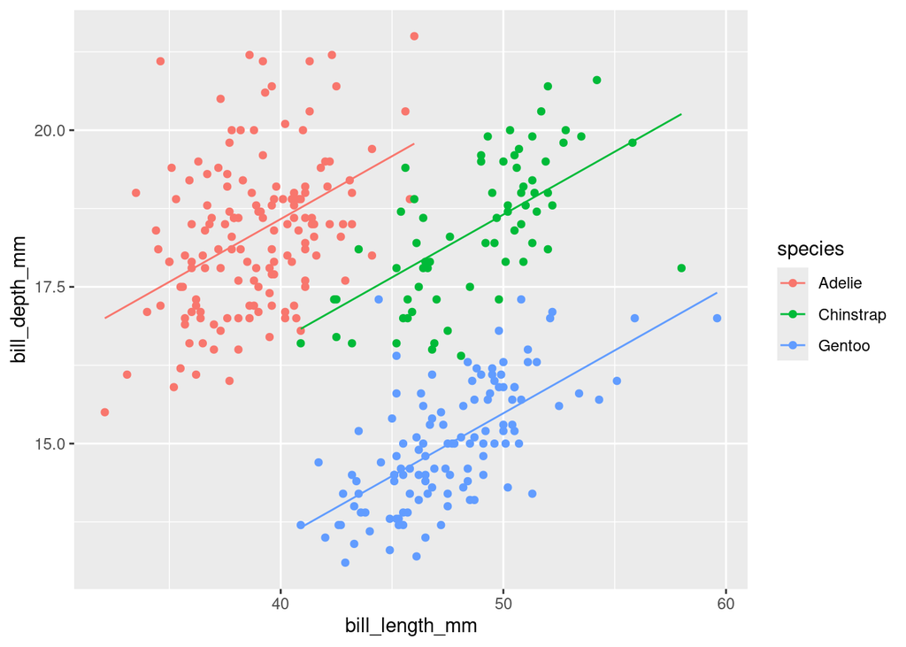

```r
penguins_clean |>
  # First add predicted values based on model
  mutate(predicted = predict(fit_model)) |>
  # Make a plot
  ggplot() +
  # Scatterplot
  geom_point(aes(x = bill_length_mm, y = bill_depth_mm, color = species)) +
  # Represent the predicted values on the regression line for each species
  geom_line(aes(x = bill_length_mm, y = predicted, color = species))
```

### c. Assessing Assumptions

Let’s check the assumptions

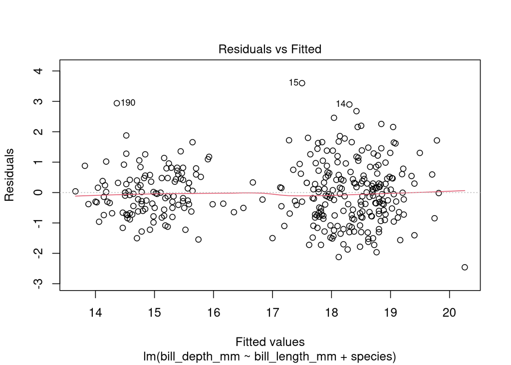

```r
# Residuals vs. Fitted values: checks for linearity and constant variance
plot(fit_model, which = 1)
```

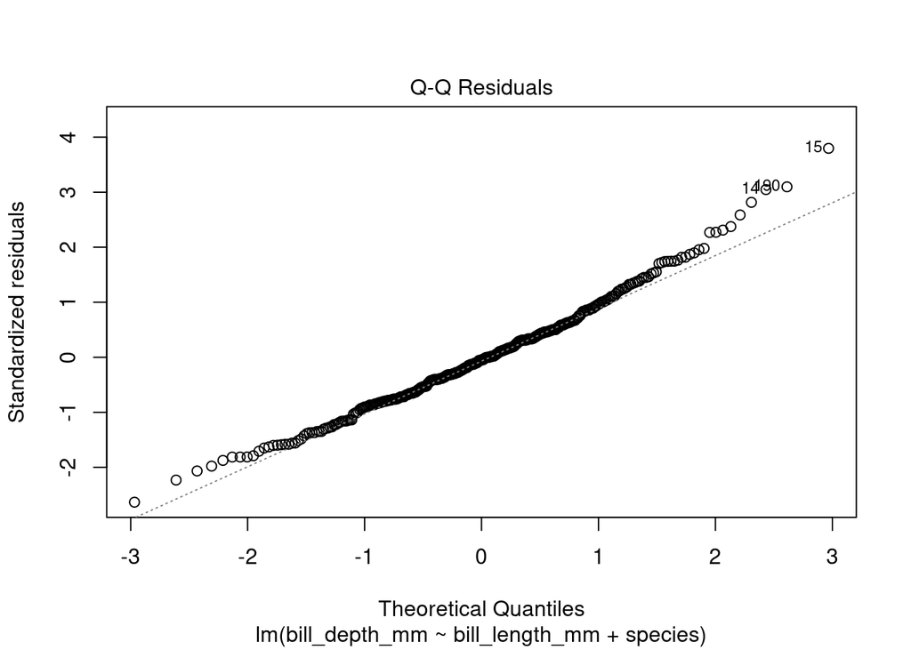

```r
# Q-Q Residuals: checks if residuals are normally distributed
plot(fit_model, which = 2)
```

There is no clear violation of linearity or normality but maybe about equal variance?

### d. Inference

We need to write a set of hypotheses for each effect (predictor) we are testing in the model:

*Hypothesis Set 1*

- H0: Controlling for species, bill length does not explain variation in bill depth.
- Ha: Controlling for species, bill length does explain variation in bill depth.

*Hypothesis Set 2*

- H0: Controlling for bill length, the different species have an equal mean bill depth.
- Ha: Controlling for bill length, the different species do not have an equal mean bill depth.

Take a look again at the model summary:

```r
# View results of the regression model
summary(fit_model)
```

```
##
## Call:
## lm(formula = bill_depth_mm ~ bill_length_mm + species, data = penguins_clean)
##
## Residuals:
##     Min      1Q  Median      3Q     Max
## -2.4579 -0.6814 -0.0431  0.5441  3.5994
##
## Coefficients:
##                  Estimate Std. Error t value Pr(>|t|)
## (Intercept)      10.56526    0.69093  15.291  < 2e-16 ***
## bill_length_mm    0.20044    0.01768  11.337  < 2e-16 ***
## speciesChinstrap -1.93308    0.22572  -8.564 4.26e-16 ***
## speciesGentoo    -5.10332    0.19440 -26.252  < 2e-16 ***
## ---
## Signif. codes:  0 '***' 0.001 '**' 0.01 '*' 0.05 '.' 0.1 ' ' 1
##
## Residual standard error: 0.9543 on 329 degrees of freedom
## Multiple R-squared:  0.7673, Adjusted R-squared:  0.7652
## F-statistic: 361.6 on 3 and 329 DF,  p-value: < 2.2e-16
```

Write the conclusion and interpret the slopes:

The linear relation between bill length and bill depth is significant, controlling for other species (t = 11.3, df = 329, p < 0.001).

The mean difference in bill depth between Adelie and Chinstrap species is significant, controlling for bill length (t = -8.5, df = 329, p < 0.001).

The mean difference in bill depth between Adelie and Gentoo species is significant, controlling for bill length (t = -26.3, df = 329, p < 0.001).

### e. Performance

Because we have more than one explanatory variable in our model, we will want to use the Adjusted R-squared to talk about model fit as R-squared can only increase:

```r
# Adjusted R-squared
summary(fit_model)$adj.r.squared
```

```
## [1] 0.765159
```

```r
# R-squared
summary(fit_model)$r.squared
```

```
## [1] 0.7672811
```

About 76.5% of the variation in bill depth is explained by our model with species and bill length.

### f. Interaction

An interaction in a multiple regression model will tell us if the effect of one explanatory variable on the response variable differs across the other explanatory variable.

Before we run the multiple regression with an interaction, we will need to mean-center our numeric predictors. To center a variable at its mean, just subtract the mean from every value in the dataset.

*Note: It is important to mean-center numeric variables that are part of interaction terms in regression models because it makes the main effects of the variables, as well as the intercept, more interpretable.*

We center the `bill_length_mm` variable:

```r
# Update the dataframe with a new variable
penguins_clean <- penguins_clean |>
  # Create a new variable
  mutate(bill_length_c = bill_length_mm - mean(bill_length_mm))
```

We can visualize the interaction:

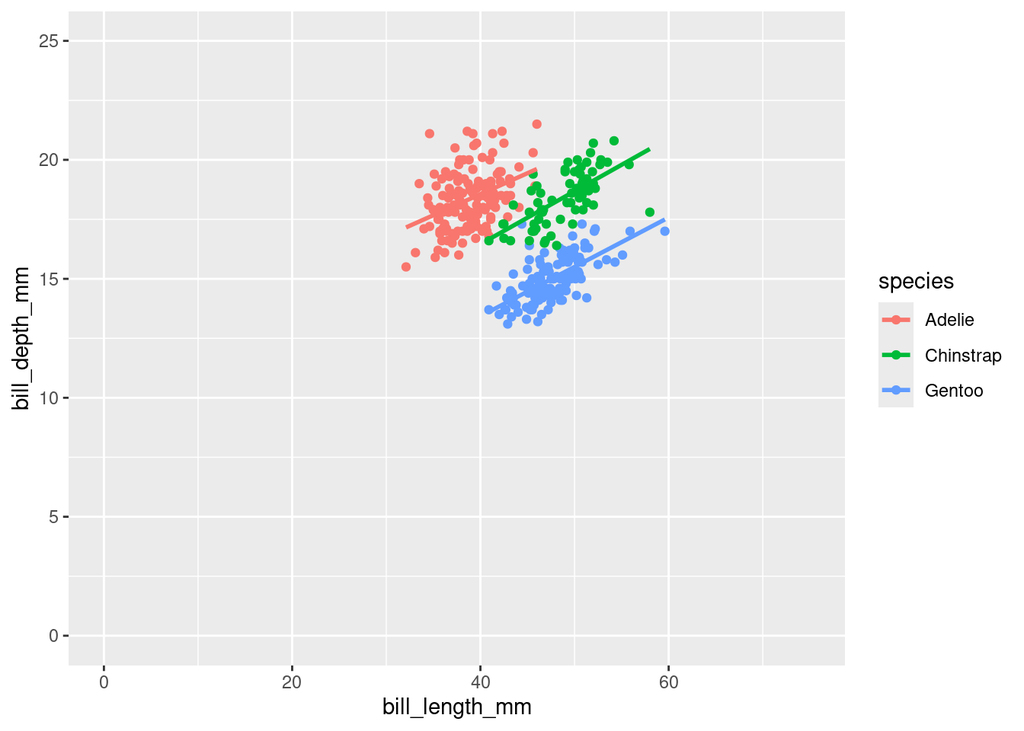

```r
penguins_clean |>
  # Make a plot
  ggplot() +
  # Scatterplot
  geom_point(aes(x = bill_length_mm, y = bill_depth_mm, color = species)) +
  # Visualize the regression line for each species
  geom_smooth(aes(x = bill_length_mm, y = bill_depth_mm, color = species),
              method = "lm", se = FALSE) +
  # Add limits to x and y-axes
  xlim(0,75) + ylim(0,25)
```

The lines are not strictly parallel anymore!

Let’s fit the model with an interaction (use `*` instead of `+`):

```r
# Fit the model with interaction
fit_model <- lm(bill_depth_mm ~ bill_length_mm * species, data = penguins_clean)

# Take a look at the model summary
summary(fit_model)
```

```
##
## Call:
## lm(formula = bill_depth_mm ~ bill_length_mm * species, data = penguins_clean)
##
## Residuals:
##     Min      1Q  Median      3Q     Max
## -2.6574 -0.6559 -0.0483  0.5203  3.4990
##
## Coefficients:
##                                 Estimate Std. Error t value Pr(>|t|)
## (Intercept)                     11.48771    1.15987   9.904  < 2e-16 ***
## bill_length_mm                   0.17668    0.02981   5.928 7.79e-09 ***
## speciesChinstrap                -3.91857    2.06731  -1.895   0.0589 .
## speciesGentoo                   -6.36675    1.77990  -3.577   0.0004 ***
## bill_length_mm:speciesChinstrap  0.04553    0.04594   0.991   0.3224
## bill_length_mm:speciesGentoo     0.03093    0.04112   0.752   0.4525
## ---
## Signif. codes:  0 '***' 0.001 '**' 0.01 '*' 0.05 '.' 0.1 ' ' 1
##
## Residual standard error: 0.9556 on 327 degrees of freedom
## Multiple R-squared:  0.7681, Adjusted R-squared:  0.7645
## F-statistic: 216.6 on 5 and 327 DF,  p-value: < 2.2e-16
```

#### **Try it! Building on your previous model to predict body mass (other than using flipper length), add `sex` as another predictor:**

- **How does this model compare to the one with only 1 predictor: is it better at predicting body mass controlling for sex?**
- **Should we consider an interaction?**

```r
# Add sex as another predictor
fit_model <- lm(body_mass_g ~ bill_length_mm + sex, data = penguins_clean)
summary(fit_model)
```

```
##
## Call:
## lm(formula = body_mass_g ~ bill_length_mm + sex, data = penguins_clean)
##
## Residuals:
##      Min       1Q   Median       3Q      Max
## -1713.57  -419.63    -0.62   513.75  1506.69
##
## Coefficients:
##                Estimate Std. Error t value Pr(>|t|)
## (Intercept)     746.063    284.851   2.619  0.00922 **
## bill_length_mm   74.025      6.667  11.102  < 2e-16 ***
## sexmale         405.243     72.818   5.565 5.43e-08 ***
## ---
## Signif. codes:  0 '***' 0.001 '**' 0.01 '*' 0.05 '.' 0.1 ' ' 1
##
## Residual standard error: 623.8 on 330 degrees of freedom
## Multiple R-squared:  0.4034, Adjusted R-squared:  0.3998
## F-statistic: 111.6 on 2 and 330 DF,  p-value: < 2.2e-16
```

```r
# If we consider an interaction
fit_model <- lm(body_mass_g ~ bill_length_mm * sex, data = penguins_clean)
summary(fit_model)
```

```
##
## Call:
## lm(formula = body_mass_g ~ bill_length_mm * sex, data = penguins_clean)
##
## Residuals:
##      Min       1Q   Median       3Q      Max
## -1690.67  -437.06    13.94   513.42  1520.26
##
## Coefficients:
##                        Estimate Std. Error t value Pr(>|t|)
## (Intercept)             537.748    421.353   1.276    0.203
## bill_length_mm           78.973      9.942   7.943 3.16e-14 ***
## sexmale                 799.571    591.814   1.351    0.178
## bill_length_mm:sexmale   -9.005     13.412  -0.671    0.502
## ---
## Signif. codes:  0 '***' 0.001 '**' 0.01 '*' 0.05 '.' 0.1 ' ' 1
##
## Residual standard error: 624.3 on 329 degrees of freedom
## Multiple R-squared:  0.4043, Adjusted R-squared:  0.3988
## F-statistic: 74.42 on 3 and 329 DF,  p-value: < 2.2e-16
```

Adding `sex` as another predictor did increase Multiple R-squared and Adjusted R-squared, so our model has improved by adding another predictor. However, Multiple R-squared and Adjusted R-squared are the same when adding an interaction (no improvement) and the interaction is not significant (t = -0.7, df = 329, p = 0.502).

## Recommended Resources

1. [R for Data Science](https://r4ds.hadley.nz/)
2. [Introductory Statistics in R](https://tjfisher19.github.io/introStatModeling/introductory-statistics-in-r.html)